# 從重複抽樣到抽樣分布的形狀

## 為什麼是 1.96？

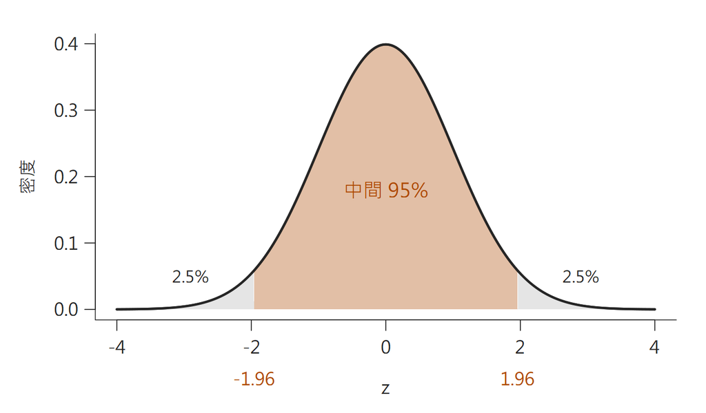

標準常態曲線：中間95%在z等於負1.96到1.96之間，兩側尾巴各2.5%。

中間 95% 的界線是 $z=\pm1.96$，所以 95% 誤差範圍是 $1.96\times\operatorname{SE}$。

IMS §13.3.3；本課程自製理論曲線；`qnorm(.975)` 為 1.96

## d、p、q、r 四族函數

| 前綴 | 回答的問題 |
| --- | --- |
| `d` | 曲線在 $x$ 的高度（密度） |
| `p` | $x$ 左側的面積（累積機率） |
| `q` | 由機率反推 $x$（分位數） |
| `r` | 隨機抽樣 |

例：`dnorm(1)`、`pnorm(1)`、`qnorm(.975)`、`rnorm(200)`。二項分布同樣有 `dbinom`、`pbinom`、`rbinom`。

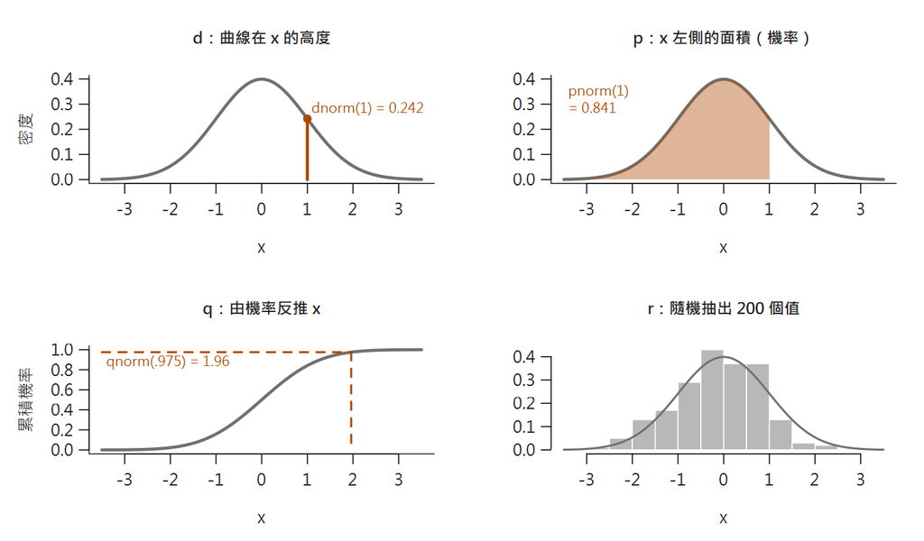

標準常態的四張小圖：d標出x等於1的曲線高度0.242；p為左側面積0.841；q由累積機率0.975反推x等於1.96；r為隨機抽出200個值的直方圖。

本課程自製示意（標準常態）；R 分布函數命名規則

## 中央極限定理：偏態母體的平均數

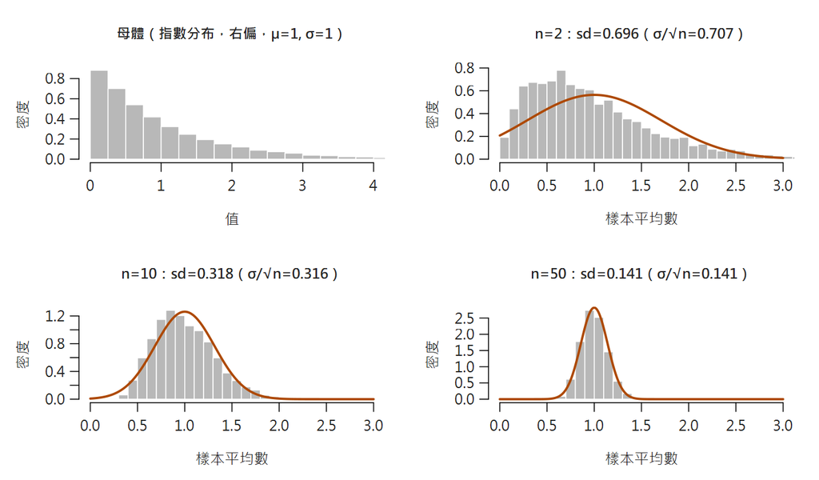

右偏的指數母體，以及n等於2、10、50的樣本平均數分布：n愈大，愈接近橘色的常態曲線，sd分別為0.696、0.318、0.141。

中央極限定理（central limit theorem，CLT）：n 愈大，樣本平均數的分布愈接近常態。

IMS §19.2.1（樣本平均數的 CLT）、§13.1（比例的 CLT）；本課程自製模擬（指數母體 μ=1、σ=1；各5000次，seed=1008）

## 中心不變，離散是 σ/√n

樣本平均數的分布：

- 中心：$\mu$
- 標準差：$\dfrac{\sigma}{\sqrt n}$
- 形狀：n 愈大愈近似常態

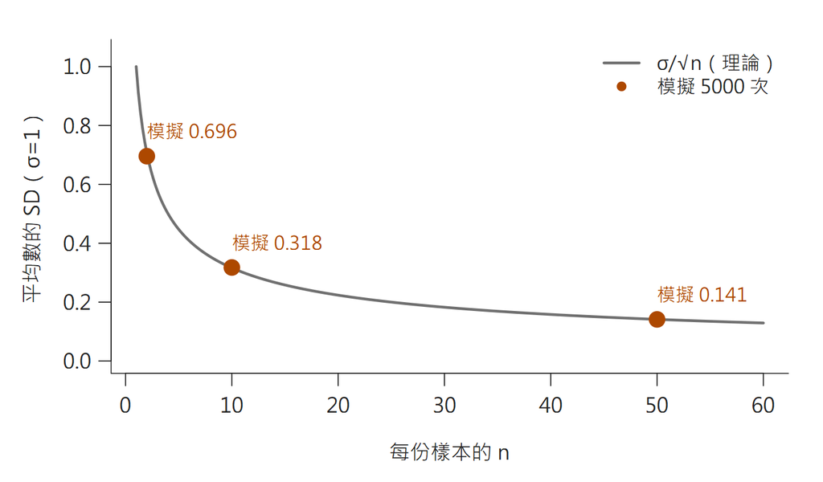

平均數的SD隨每份樣本的n增加而下降，曲線為σ除以根號n；n等於2、10、50的模擬值約0.696、0.318、0.141，落在曲線上。

IMS §19.2.1；本課程自製模擬（σ=1，seed=1008）

## 大數法則與 CLT 的差別

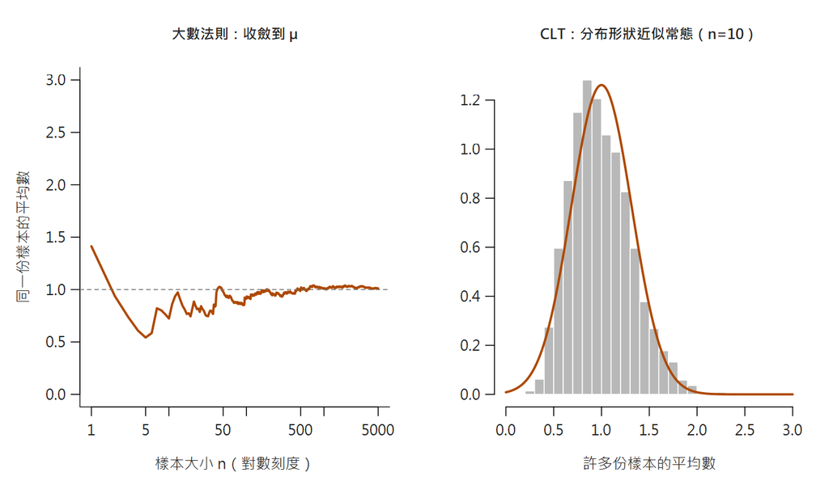

左圖：累積觀察數n增加，樣本平均數趨近母體平均1；右圖：許多份n等於10的樣本平均數，呈現固定n下的抽樣分布。

|  | 回答的問題 |
| --- | --- |
| 大數法則 | 累積觀察數 $n$ 增加，樣本平均數趨近 $\mu$ |
| CLT | 每份樣本的 $n$ 增加，平均數的抽樣分布漸近常態 |

本課程自製模擬（指數母體，seed=57 與 1008）

## 母體越偏，需要越大的 n

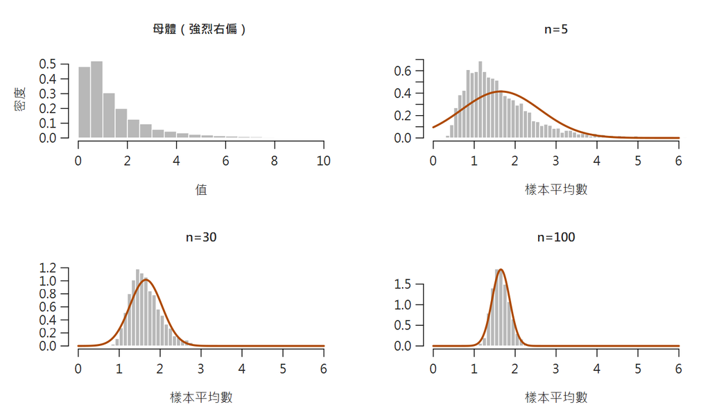

強烈右偏的母體；n等於5、30、100的樣本平均數分布與常態曲線。n等於30仍可見右偏，n等於100較貼近常態。

樣本數夠不夠，依母體的偏態程度而定；比例則看預期成功與失敗各至少 10 次。

課本對平均數的粗略指引：輕度偏態 n 約 15，中度約 30，強烈約 60。

IMS §13.1、§19.2.2（粗略指引，p.332）；本課程自製模擬（對數常態母體，4000次，seed=58）

## 練習 3｜用 z 分數比較相對表現

Sophia 的 GRE 兩科成績如下。假設兩科分布都近似常態。

| 科目 | 成績 | 母體平均 | 母體 SD |
| --- | --- | --- | --- |
| 語文推理 | 160 | 151 | 7 |
| 量化推理 | 157 | 153 | 7.67 |

1. 算出兩科的 z 分數，說明其意義。
2. 相較於各科考生，她哪科表現較好？為什麼不能只比原始分數？

**答案與解析**

- 語文：$z=(160-151)/7\approx1.29$。
- 量化：$z=(157-153)/7.67\approx0.52$。
- 分別高於各科平均約 **1.29、0.52 個 SD**；語文的相對表現較好。
- 兩科的平均與 SD 不同；z 分數讓我們用相同單位比較相對位置。

IMS 2e §13.8，習題 13.3(b–d, g)，p.240；中文節選改寫，數值沿用課本；答案核對 Appendix A.13

## 練習 4｜重複抽取飲用水樣本

某組織估計飲用水鉛含量偏高的家戶比例 $p$ 約在 5%–30%。每次隨機抽 **800 戶**並算出比例，重複 **1,000 次**。

假設家戶觀察彼此獨立。

1. 這 1,000 個比例形成什麼分布？其標準差稱為什麼？
2. 分布能近似常態嗎？說明條件。
3. 每次改抽 250 戶，仍重複 1,000 次，分布會更寬或更窄？

**答案與解析**

- 是**樣本比例的抽樣分布**；其標準差稱為 **SE**。
- 可以近似常態：$np\ge40$、$n(1-p)\ge560$，都至少 10。
- 改抽 250 戶，SE 增大：

$$\frac{\operatorname{SE}_{250}}{\operatorname{SE}_{800}}=\sqrt{\frac{800}{250}}\approx1.79$$

**n 是每份樣本的戶數；1,000 是重複次數。**

IMS 2e §13.8，習題 13.15(a–d)，p.244；中文改寫，數值沿用課本；獨立抽樣、固定 p 的模型

## Slido｜Part 1

概念題 1–3，匿名作答。[開啟 Slido](https://app.sli.do/event/827K2CiPQiuULcdfLtqLAV)｜活動代碼 **3662547**

[figure not shown]

Week 05 Slido 作答入口 QR code；活動代碼 3662547。

Week05 Part 1 Slido；本課程自編概念題 1–3